# Hand Writing Recognision

# MODELING

## Random Forest

Random forest is developed by aggregation of trees. This can be used for both regression and classification problems. It can deal with large number of features and avoid overfitting. `params : ntree > default = 500, mtry > default = sq.root(p) for classification, p/3 for regression`. p is the number of features.

### Model 1

The first random forest model is build with the default parameters using the randomForest packages in R.

```r
(rf_model1 <- randomForest(label ~ ., data = X_train_with_label))
```

```
##
## Call:
##  randomForest(formula = label ~ ., data = X_train_with_label)
##                Type of random forest: classification
##                      Number of trees: 500
## No. of variables tried at each split: 28
##
##         OOB estimate of  error rate: 9.74%
## Confusion matrix:
##    0   1   2   3   4  5   6   7   8   9 class.error
## 0 95   0   0   0   0  1   2   1   3   0  0.06862745
## 1  0 118   1   0   0  1   0   1   0   0  0.02479339
## 2  1   2 104   0   0  1   0   2   1   2  0.07964602
## 3  1   1   6 112   0  3   0   2   3   2  0.13846154
## 4  0   0   0   0 116  0   1   1   4   6  0.09375000
## 5  1   1   0  12   2 95   1   0   0   2  0.16666667
## 6  0   0   1   0   2  2 109   1   1   0  0.06034483
## 7  0   2   1   0   2  0   1 139   0   6  0.07947020
## 8  0   3   0   8   1  2   1   1 101   5  0.17213115
## 9  1   0   1   2   5  0   0   4   0 132  0.08965517
```

```r
print(rf_model1)
```

```
##
## Call:
##  randomForest(formula = label ~ ., data = X_train_with_label)
##                Type of random forest: classification
##                      Number of trees: 500
## No. of variables tried at each split: 28
##
##         OOB estimate of  error rate: 9.74%
## Confusion matrix:
##    0   1   2   3   4  5   6   7   8   9 class.error
## 0 95   0   0   0   0  1   2   1   3   0  0.06862745
## 1  0 118   1   0   0  1   0   1   0   0  0.02479339
## 2  1   2 104   0   0  1   0   2   1   2  0.07964602
## 3  1   1   6 112   0  3   0   2   3   2  0.13846154
## 4  0   0   0   0 116  0   1   1   4   6  0.09375000
## 5  1   1   0  12   2 95   1   0   0   2  0.16666667
## 6  0   0   1   0   2  2 109   1   1   0  0.06034483
## 7  0   2   1   0   2  0   1 139   0   6  0.07947020
## 8  0   3   0   8   1  2   1   1 101   5  0.17213115
## 9  1   0   1   2   5  0   0   4   0 132  0.08965517
```

```r
rf_model1$mtry
```

```
## [1] 28
```

## Make prediction on new datasets

```r
prediction  <- predict(rf_model1, X_test)
```

The confusion matrix of the model performance. The method is from the package caret.

```r
confusionMatrix(prediction, y_test)
```

```
## Confusion Matrix and Statistics
##
##           Reference
## Prediction   0   1   2   3   4   5   6   7   8   9
##          0 250   0   2   2   0   3   6   0   1   1
##          1   0 294   6   5   1   4   2   3   2   3
##          2   2   0 287   4   3   1   3   2   3   1
##          3   0   2   1 285   0  23   0   1   7   0
##          4   0   0   5   1 260   0   2   4   0   9
##          5   0   0   0   6   0 207   3   0   4   0
##          6   3   0   5   0   4   5 276   0   1   1
##          7   0   0   8   7   3   6   2 284   1   8
##          8   7   1   4   4   2   3   1   0 249   4
##          9   0   0   6   2  15   3   0  18   5 226
##
## Overall Statistics
##
##                Accuracy : 0.9106
##                  95% CI : (0.8996, 0.9208)
##     No Information Rate : 0.1127
##     P-Value [Acc > NIR] : < 2.2e-16
##
##                   Kappa : 0.9006
##
##  Mcnemar's Test P-Value : NA
##
## Statistics by Class:
##
##                      Class: 0 Class: 1 Class: 2 Class: 3 Class: 4 Class: 5
## Sensitivity           0.95420   0.9899  0.88580  0.90190  0.90278  0.81176
## Specificity           0.99426   0.9899  0.99255  0.98671  0.99188  0.99504
## Pos Pred Value        0.94340   0.9188  0.93791  0.89342  0.92527  0.94091
## Neg Pred Value        0.99540   0.9988  0.98560  0.98787  0.98921  0.98192
## Prevalence            0.09113   0.1033  0.11270  0.10991  0.10017  0.08870
## Detection Rate        0.08696   0.1023  0.09983  0.09913  0.09043  0.07200
## Detection Prevalence  0.09217   0.1113  0.10643  0.11096  0.09774  0.07652
## Balanced Accuracy     0.97423   0.9899  0.93918  0.94431  0.94733  0.90340
##                      Class: 6 Class: 7 Class: 8 Class: 9
## Sensitivity            0.9356  0.91026  0.91209  0.89328
## Specificity            0.9926  0.98634  0.99001  0.98131
## Pos Pred Value         0.9356  0.89028  0.90545  0.82182
## Neg Pred Value         0.9926  0.98905  0.99077  0.98962
## Prevalence             0.1026  0.10852  0.09496  0.08800
## Detection Rate         0.0960  0.09878  0.08661  0.07861
## Detection Prevalence   0.1026  0.11096  0.09565  0.09565
## Balanced Accuracy      0.9641  0.94830  0.95105  0.93730
```

## Error rate

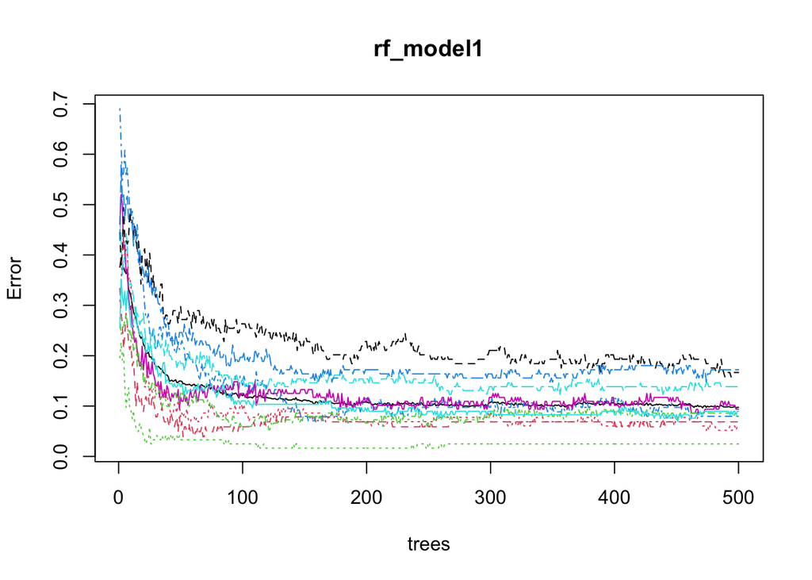

```r
plot(rf_model1)
```

When number of tree is around 200, the error rate become contant and no significatnt improvement.

## Tune the model parameters

ntreeTry = 200

```
## mtry = 28  OOB error = 9.82%
## Searching left ...
## Searching right ...
```

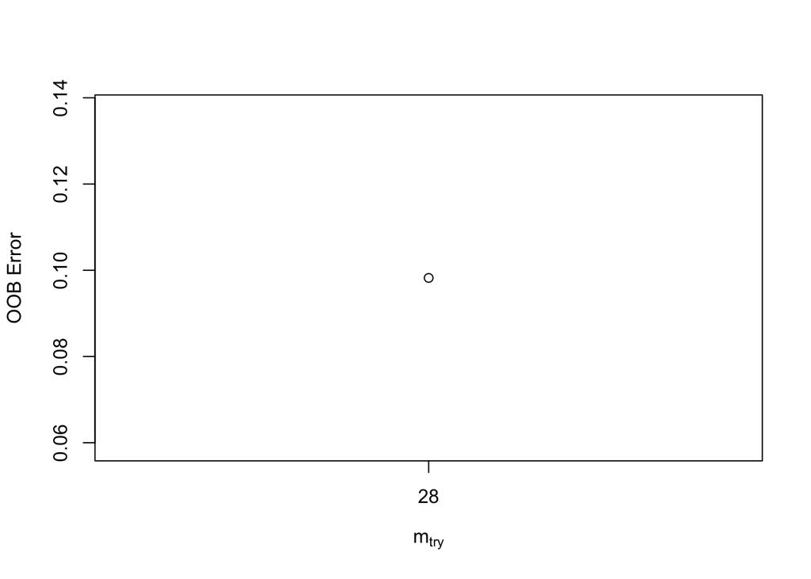

```
##        mtry   OOBError
## 28.OOB   28 0.09822866
```

```r
tuneRF(X_train, y_train,
       stepFactor = 1,
       plot = TRUE,
       ntreeTry = 200,
       trace = TRUE,
       improve = 0.1)
```

## Random Forest Parameters

ntree = 200 mtry = 28

## Build a random forest model with ntree = 200, mtry =28

## Model 2

```r
rf_model2 <- randomForest(label~.,data = X_train_with_label, ntree=200, mtry=28)
```

```r
print(rf_model2)
```

```
##
## Call:
##  randomForest(formula = label ~ ., data = X_train_with_label,      ntree = 200, mtry = 28)
##                Type of random forest: classification
##                      Number of trees: 200
## No. of variables tried at each split: 28
##
##         OOB estimate of  error rate: 9.34%
## Confusion matrix:
##    0   1   2   3   4  5   6   7   8   9 class.error
## 0 97   0   0   0   0  1   2   0   2   0  0.04901961
## 1  0 118   0   1   0  1   0   1   0   0  0.02479339
## 2  0   2 103   2   0  0   1   3   1   1  0.08849558
## 3  0   0   5 112   2  2   0   1   4   4  0.13846154
## 4  0   0   0   0 118  0   1   1   2   6  0.07812500
## 5  0   0   0  13   2 95   1   0   2   1  0.16666667
## 6  0   0   1   0   0  2 111   1   1   0  0.04310345
## 7  0   2   2   0   4  0   0 135   1   7  0.10596026
## 8  1   1   1   6   1  3   1   1 103   4  0.15573770
## 9  1   0   1   2   4  0   0   3   0 134  0.07586207
```

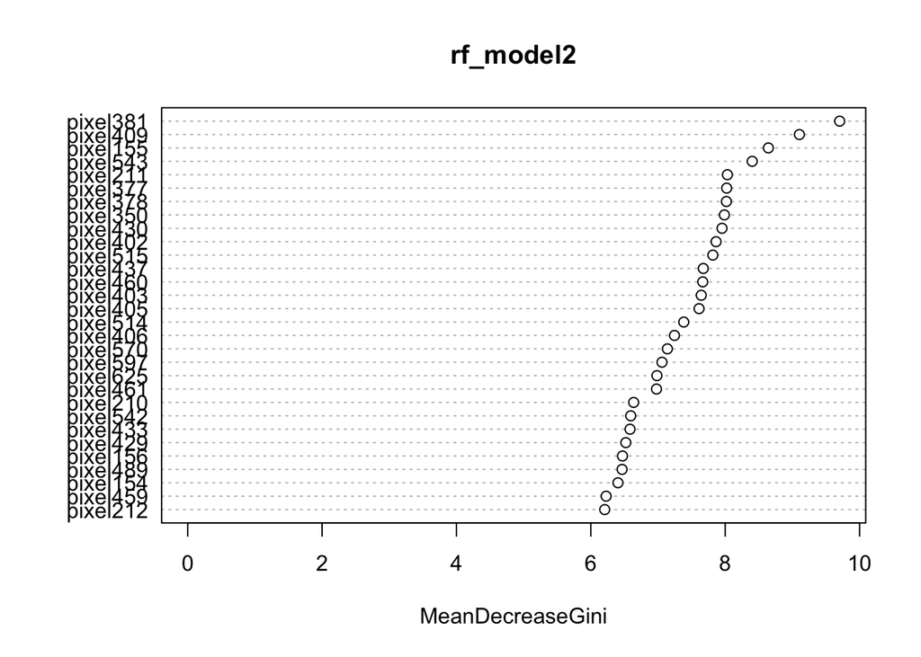

```r
varImpPlot(rf_model2)
```

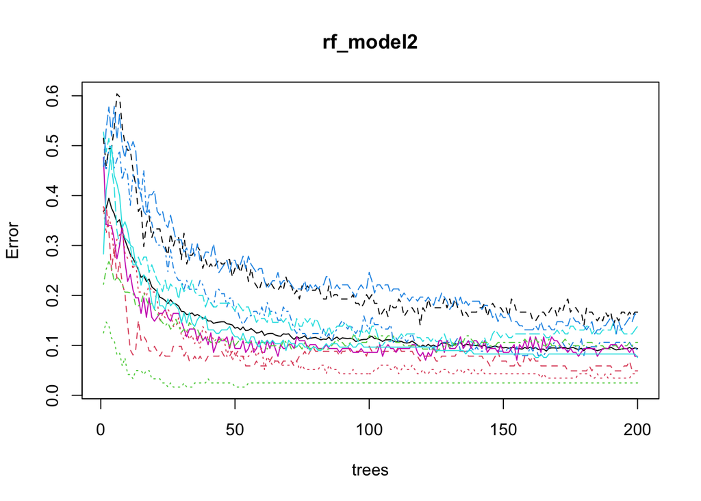

```r
plot(rf_model2)
```

## Tree size

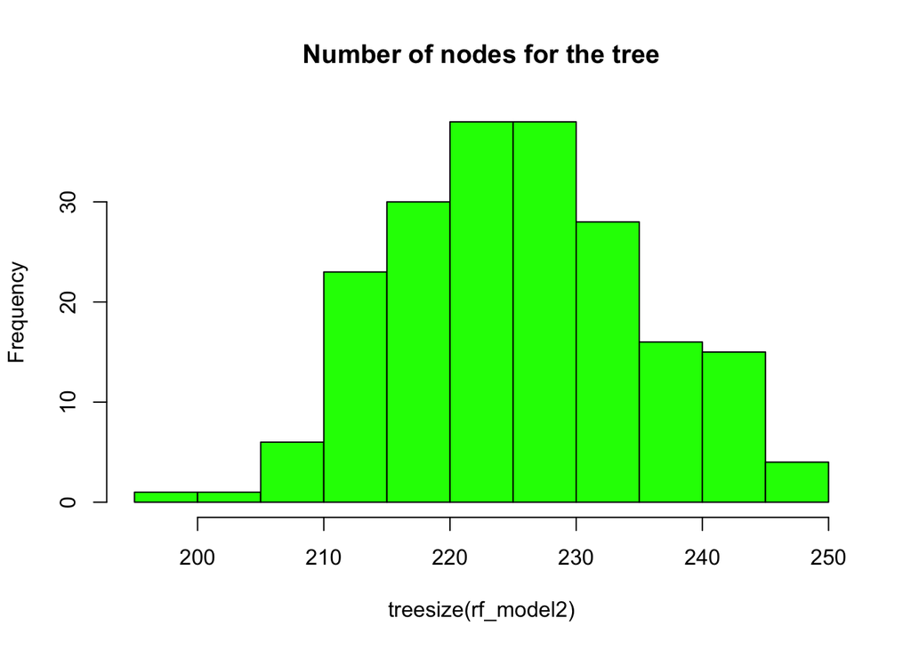

```r
hist(treesize(rf_model2), main = "Number of nodes for the tree", col='green')
```

```r
#h <- figure(width = 600, height = 400, xlab = 'Tree Size') %>%
  #ly_hist(treesize(rf_model2), breaks = 40, freq = FALSE) %>%
 # ly_density(treesize(rf_model2))
#h
```

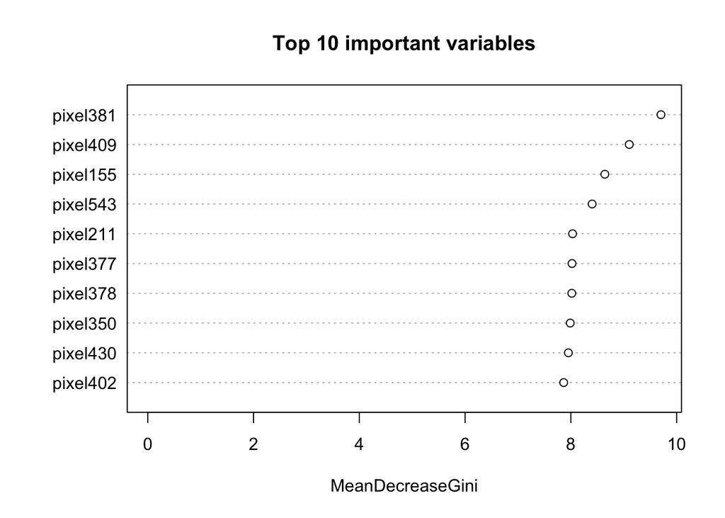

```r
varImpPlot(rf_model2, sort = TRUE, n.var = 10, main = "Top 10 important variables")
```

## Prediction

```r
p2 <- predict(rf_model2, X_test)

confusionMatrix(p2, y_test)
```

```
## Confusion Matrix and Statistics
##
##           Reference
## Prediction   0   1   2   3   4   5   6   7   8   9
##          0 251   0   1   2   1   3   5   0   2   1
##          1   0 294   5   4   1   3   2   3   3   2
##          2   1   0 289   5   3   1   1   2   4   1
##          3   0   2   2 284   0  22   0   1   7   0
##          4   0   0   6   1 255   0   0   4   0  10
##          5   2   0   0   6   0 214   1   0   3   1
##          6   4   0   4   0   3   2 281   0   1   1
##          7   0   0   8   7   5   5   2 284   2   8
##          8   4   1   6   3   2   2   2   0 247   5
##          9   0   0   3   4  18   3   1  18   4 224
##
## Overall Statistics
##
##                Accuracy : 0.9123
##                  95% CI : (0.9014, 0.9224)
##     No Information Rate : 0.1127
##     P-Value [Acc > NIR] : < 2.2e-16
##
##                   Kappa : 0.9025
##
##  Mcnemar's Test P-Value : NA
##
## Statistics by Class:
##
##                      Class: 0 Class: 1 Class: 2 Class: 3 Class: 4 Class: 5
## Sensitivity           0.95802   0.9899   0.8920  0.89873   0.8854  0.83922
## Specificity           0.99426   0.9911   0.9929  0.98671   0.9919  0.99504
## Pos Pred Value        0.94361   0.9274   0.9414  0.89308   0.9239  0.94273
## Neg Pred Value        0.99578   0.9988   0.9864  0.98749   0.9873  0.98452
## Prevalence            0.09113   0.1033   0.1127  0.10991   0.1002  0.08870
## Detection Rate        0.08730   0.1023   0.1005  0.09878   0.0887  0.07443
## Detection Prevalence  0.09252   0.1103   0.1068  0.11061   0.0960  0.07896
## Balanced Accuracy     0.97614   0.9905   0.9425  0.94272   0.9386  0.91713
##                      Class: 6 Class: 7 Class: 8 Class: 9
## Sensitivity           0.95254  0.91026  0.90476  0.88538
## Specificity           0.99419  0.98556  0.99039  0.98055
## Pos Pred Value        0.94932  0.88474  0.90809  0.81455
## Neg Pred Value        0.99457  0.98904  0.99001  0.98885
## Prevalence            0.10261  0.10852  0.09496  0.08800
## Detection Rate        0.09774  0.09878  0.08591  0.07791
## Detection Prevalence  0.10296  0.11165  0.09461  0.09565
## Balanced Accuracy     0.97336  0.94791  0.94758  0.93296
```

## prepared submission to kaggle

```r
prediction <- predict(rf_model2, digit_test)

submission<-data.frame(ImageId=1:nrow(digit_test),Label=prediction)


write.csv(submission, file="rfsubmission.csv", row.names=F)
```

## Save the model

```r
saveRDS(rf_model2, './randomForest_model2_digit.rds')
```

## KNN

KNN is a supervised learning algorithm, which means we are given a labelled training sample with its corresponding training features to train the model.

## Model 1

```r
k <- round(sqrt(nrow(X_train)))

knn_Model <- class::knn(train = X_train, test = X_test, cl=y_train, k=k, prob = TRUE)
```

## Model Performance

```r
table(knn_Model, y_test)
```

```
##          y_test
## knn_Model   0   1   2   3   4   5   6   7   8   9
##         0 236   0   3   1   0   3   5   0   3   1
##         1   4 297  71  22  21  26  14   8  35  12
##         2   1   0 210   2   0   0   0   1   1   0
##         3   2   0   4 266   0  31   0   0  12   0
##         4   0   0   6   0 186   3   3   1   1   3
##         5   2   0   1   3   0 166   3   0   6   1
##         6  13   0   2   1   3   6 268   0   0   1
##         7   1   0  13   9   6   6   1 282   2  22
##         8   1   0   8   5   0   1   0   0 201   0
##         9   2   0   6   7  72  13   1  20  12 213
```

```r
CrossTable(x = y_test, y = knn_Model,prop.chisq=F)
```

```
##    Cell Contents
## |-------------------------|
## |                       N |
## |           N / Row Total |
## |           N / Col Total |
## |         N / Table Total |
## |-------------------------|
##
## ===============================================================================================
##           knn_Model
## y_test        0       1       2       3       4       5       6       7       8       9   Total
## -----------------------------------------------------------------------------------------------
## 0           236       4       1       2       0       2      13       1       1       2     262
##           0.901   0.015   0.004   0.008   0.000   0.008   0.050   0.004   0.004   0.008   0.091
##           0.937   0.008   0.005   0.006   0.000   0.011   0.044   0.003   0.005   0.006
##           0.082   0.001   0.000   0.001   0.000   0.001   0.005   0.000   0.000   0.001
## -----------------------------------------------------------------------------------------------
## 1             0     297       0       0       0       0       0       0       0       0     297
##           0.000   1.000   0.000   0.000   0.000   0.000   0.000   0.000   0.000   0.000   0.103
##           0.000   0.582   0.000   0.000   0.000   0.000   0.000   0.000   0.000   0.000
##           0.000   0.103   0.000   0.000   0.000   0.000   0.000   0.000   0.000   0.000
## -----------------------------------------------------------------------------------------------
## 2             3      71     210       4       6       1       2      13       8       6     324
##           0.009   0.219   0.648   0.012   0.019   0.003   0.006   0.040   0.025   0.019   0.113
##           0.012   0.139   0.977   0.013   0.030   0.005   0.007   0.038   0.037   0.017
##           0.001   0.025   0.073   0.001   0.002   0.000   0.001   0.005   0.003   0.002
## -----------------------------------------------------------------------------------------------
## 3             1      22       2     266       0       3       1       9       5       7     316
##           0.003   0.070   0.006   0.842   0.000   0.009   0.003   0.028   0.016   0.022   0.110
##           0.004   0.043   0.009   0.844   0.000   0.016   0.003   0.026   0.023   0.020
##           0.000   0.008   0.001   0.093   0.000   0.001   0.000   0.003   0.002   0.002
## -----------------------------------------------------------------------------------------------
## 4             0      21       0       0     186       0       3       6       0      72     288
##           0.000   0.073   0.000   0.000   0.646   0.000   0.010   0.021   0.000   0.250   0.100
##           0.000   0.041   0.000   0.000   0.916   0.000   0.010   0.018   0.000   0.208
##           0.000   0.007   0.000   0.000   0.065   0.000   0.001   0.002   0.000   0.025
## -----------------------------------------------------------------------------------------------
## 5             3      26       0      31       3     166       6       6       1      13     255
##           0.012   0.102   0.000   0.122   0.012   0.651   0.024   0.024   0.004   0.051   0.089
##           0.012   0.051   0.000   0.098   0.015   0.912   0.020   0.018   0.005   0.038
```

[output cut: 10 more lines]

```
##           0.000   0.003   0.000   0.000   0.000   0.000   0.000   0.098   0.000   0.007
## -----------------------------------------------------------------------------------------------
## 8             3      35       1      12       1       6       0       2     201      12     273
##           0.011   0.128   0.004   0.044   0.004   0.022   0.000   0.007   0.736   0.044   0.095
##           0.012   0.069   0.005   0.038   0.005   0.033   0.000   0.006   0.931   0.035
##           0.001   0.012   0.000   0.004   0.000   0.002   0.000   0.001   0.070   0.004
## -----------------------------------------------------------------------------------------------
## 9             1      12       0       0       3       1       1      22       0     213     253
##           0.004   0.047   0.000   0.000   0.012   0.004   0.004   0.087   0.000   0.842   0.088
##           0.004   0.024   0.000   0.000   0.015   0.005   0.003   0.064   0.000   0.616
##           0.000   0.004   0.000   0.000   0.001   0.000   0.000   0.008   0.000   0.074
## -----------------------------------------------------------------------------------------------
## Total       252     510     215     315     203     182     294     342     216     346    2875
##           0.088   0.177   0.075   0.110   0.071   0.063   0.102   0.119   0.075   0.120
## ===============================================================================================
```